# Hw1

Sean Raglow Elec 542 Hw 1

a)

Consider one electron in a one-dimensional, infinitely deep well with a width of 10 atomic units. \begin{align} V(x) = \begin{cases} & 0 \quad \quad \text{if} \quad 0 < x < 10 \nonumber \\ & \infty \quad \quad \text{otherwise} \end{cases} \end{align} outside the well, we know $\psi(x) = 0$. Furthermore, at the boundary of the well we have $\psi(0) = \psi(10) = 0$ since the potential is zero inside the well, from Schr\"odinger's equation we have \begin{align} -\frac{1}{2m} \frac{d^2\psi}{dx^2} = E \psi \nonumber \\ \frac{d^2\psi}{dx^2} = -k^2 \psi \end{align} where $k = \sqrt{2mE}$ which is simply the equation for a harmonic oscillator, which has a general solution of a sum of sine and cosine waves \begin{align} \psi(x) = A \sin(kx) + B \cos(kx) \end{align} applying the boundary conditions forces $B=0$ and $k = \frac{n \pi}{10}$ where $n \in \mathbb{N}$. This gives \begin{align} \psi_n(x) = A \sin(\frac{n \pi}{10}x) \end{align} Normalizing this so that $\int \psi^\star \psi dx = 1$, gives $A = \sqrt{\frac{2}{10}}$. Thus finally we have $$ \boxed{\psi_n(x) = \sqrt{\frac{2}{10}} \sin(\frac{n \pi}{10}x)} $$ These eigenstates have energies \begin{align} \boxed{E_n = \frac{n^2 \pi^2}{200m}} \end{align} The eigenstates are plotted below

```python
import matplotlib.pyplot as plt
import numpy as np

n = 6
# m = 9.1*10**(-31)
# hbar = 1.054571817*10**(-34)
m = 1
hbar = 1


x = np.linspace(0,10,num=200)

fig, ax = plt.subplots(6, figsize=(10,8), dpi = 1000)

E = np.zeros(n)
for i in range(n):
    E[i] =  (i+1)**2 * np.pi**2 /(200*m)

    y = np.sqrt(2/10) * np.sin((i+1)*np.pi/10*x)

    ax[i].plot(x, y, label='$\psi_{}, E_{}$={:>8.3f}'.format(i+1,i+1, E[i] ), color=(1-i/6,0,i/6))

fig.legend()
fig.suptitle('Plot for part a')
plt.savefig('PartaPlot.png')
plt.show()
```

[figure not shown]

b)

To solve the same problem numerically in python, I rewrote the equation in matrix form using finite methods and then used numpy's 'eig' function to solve for the eigenvalues and eigenvectors. to write Schrödinger's equation \begin{align} -\frac{1}{2m} \frac{d^2\psi}{dx^2} = E \psi \end{align} in matrix form, we must discretize the domain and realize that the second derivative with respect to x can be written as a finite difference $$ \frac{d^2\psi_i}{dx^2} = \frac{\psi_{i+1} - 2 \psi_i + \psi_{i-1}}{h^2} $$ where $h = x_{i+1} - x_i$ is the stepsize. Thus we can write our equation as \begin{align} H \psi = E \psi \end{align} where $$ H = \frac{1}{h^2}\begin{bmatrix} -2 & 1 & 0 & 0 & \cdots \\ 1 & -2 & 1 & 0 & \cdots \\ 0 & 1 & -2 & 1 & \cdots \\ \vdots & \vdots & \vdots & \ddots & \ddots \\ 0 & \cdots & 0 & 1 & -2 \end{bmatrix} $$

The eigenvalues of this matrix are the energies of our system, and the eigenvectors are the wave functions. Below is the code we used to compute all of this, and a plot of the first 6 eigenvectors. In the legend you can see that the Energies are very close to the energies we got from the analytical method above.

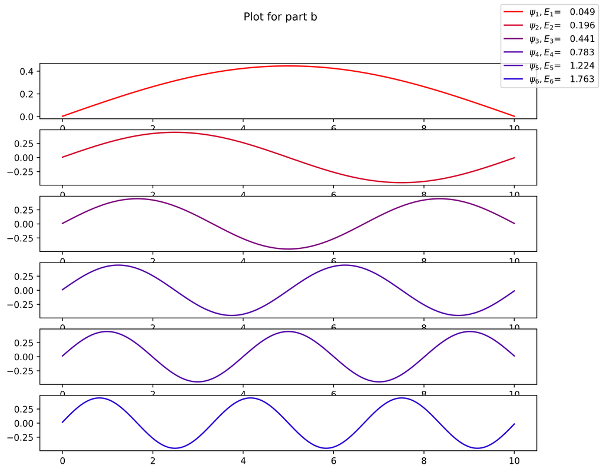

```python
N = 512 #number of steps
a = 10 #size of quantum well
x = np.linspace(0,a,N)
h = x[1]-x[0] # Step size, Should be equal to 2*np.pi/(N-1)
V = 0.*x
Mdd = 1./(h*h)*(np.diag(np.ones(N-1),-1) -2* np.diag(np.ones(N),0) + np.diag(np.ones(N-1),1))
H = -(hbar*hbar)/(2.0*m)*Mdd + np.diag(V)
E,psiT = np.linalg.eigh(H) # This computes the eigen values and eigenvectors
psi = np.transpose(psiT)   # We take the transpose of psiT to the wavefunction vectors can accessed as psi[n]


fig, ax = plt.subplots(6, figsize=(10,8), dpi = 500)
for i in range(6):
    if psi[i][10] < 0:   # Flip the wavefunctions if it is negative at small x, so plots are more consistent.
        ax[i].plot(x,-psi[i]/np.sqrt(h),label="$\psi_{}, E_{}$={:>8.3f}".format(i+1,i+1,E[i]), color=(1-i/6,0,i/6))
    else:
        ax[i].plot(x,psi[i]/np.sqrt(h),label="$\psi_{}, E_{}$={:>8.3f}".format(i+1,i+1,E[i]), color=(5/6-i/6,0,1/6+i/6))

fig.legend()
fig.suptitle('Plot for part b')
plt.savefig('PartbPlot.png')
plt.show()
```

c)

If we now add another electron to our system, then Schrödinger's equation becomes $$ -\frac{1}{2m}\left( \frac{d^2\psi}{dx_1^2} + \frac{d^2\psi}{dx_2^2} \right) = E \psi(x_1,x_2) $$ We now have two x-variables, one for the position of each electron. To discretize this, we must discretize $x_1$ and $x_2$ into a 2d grid, and then order that grid so we can write eigenstates as a normal vector.

If the grid is N x N then each vector will have $N*N$ entries. I am choosing to order my vectors so that the (i+j*N)th entry corresponds to the value of the wavefunction at the ith $x_1$ value and the jth $x_2$ value. The approximated discrete Hamiltonian is given by \begin{align} H = \frac{-1}{2m h^2} \left(\psi_{i-1,j} + \psi_{i+1,j} + \psi_{i,j-1} + \psi_{i,j+1} - 4\psi_{i,j} \right) \end{align}

which will be a N*N by N*N matrix that is block tridiagonal. Below is the code I used to implement this method, with plots for the six lowest energy states.

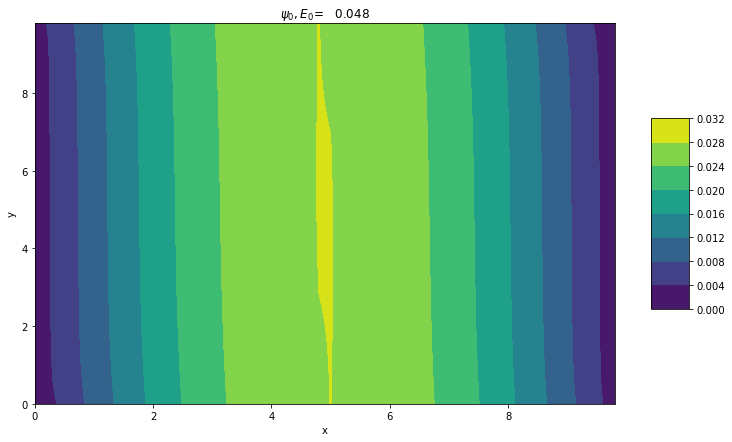

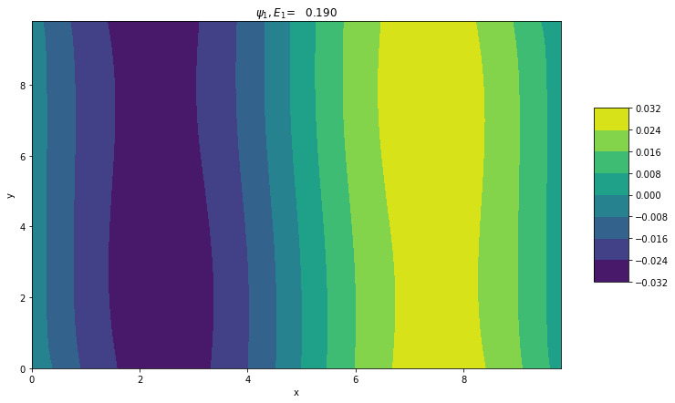

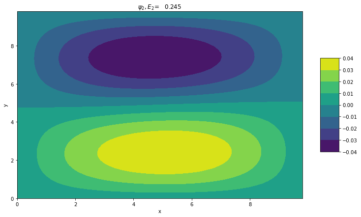

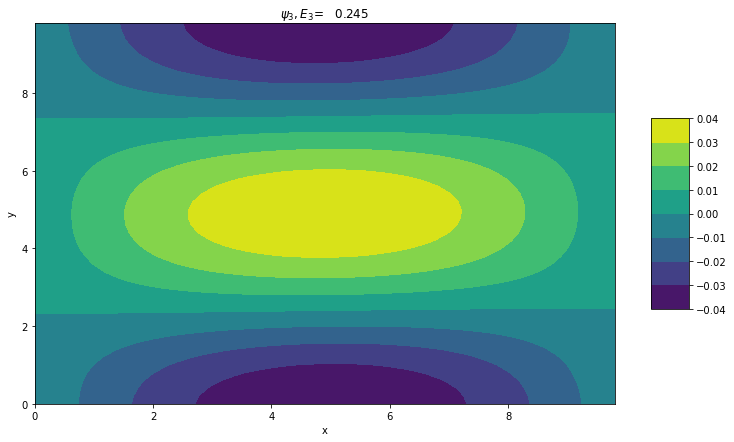

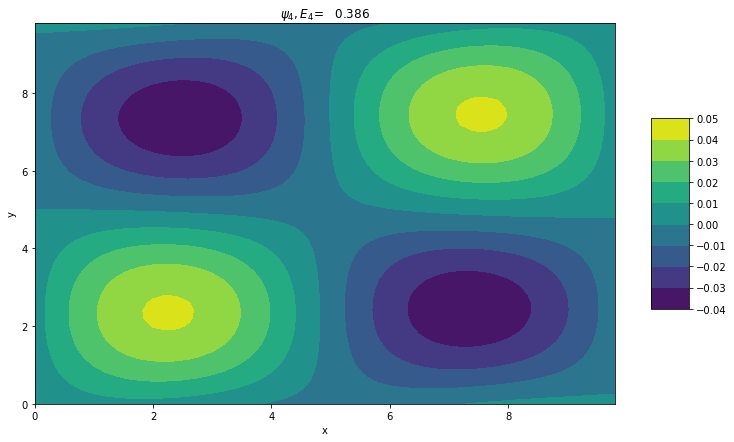

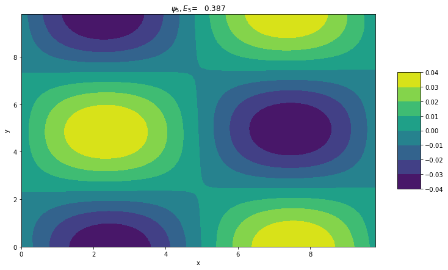

```python
import numpy as np
import matplotlib.pyplot as plt


hbar=1
m=1
N = 50
a = 10
h = a/N
x,y = np.mgrid[0:a:h, 0:a:h]
# x = np.linspace(0,a,N)
# y = np.linspace(0,a,N)

#build the Hamiltonian Matrix
Mdd = 1./(h*h)*(np.diag(np.ones(N*N-1),-1) -4* np.diag(np.ones(N*N),0) + \
    np.diag(np.ones(N*N-1),1) + np.diag(np.ones(N*N-N),N) + \
    np.diag(np.ones(N*N-N),-N))
H = -(hbar*hbar)/(2.0*m)*Mdd


E,psiT = np.linalg.eigh(H) # This computes the eigen values and eigenvectors
psi = np.transpose(psiT)   # We take the transpose of psiT to the wavefunction vectors can accessed as psi[n]



for i in range(6):
    fig = plt.figure(figsize=(13, 7))
    ax = plt.axes()
    surf = ax.contourf(x, y, np.reshape(psi[i],(N,N)))

    ax.set_xlabel('x')
    ax.set_ylabel('y')
    ax.set_title("$\psi_{}, E_{}$={:>8.3f}".format(i, i,E[i]))
    fig.colorbar(surf, shrink=0.5, aspect=5) # add color bar indicating the PDF
```

The wavefunctions and energies above do not match up with the wavefunctions that I expect to see from 2 non-interacting electrons in an infinite square well... I spent quite some time trying to troubleshoot, but in the end I could not figure out what I did wrong. Ultimately, it's fairly close, but something in my code is off.

d)

If we add coulomb interactions between the two electrons in, then we can keep everything from the Hamiltonian in part c, and add to it a new matrix $V$ given by $$ V = \frac{1}{|j-i|h}\psi_{i,j} $$ This will have infinties whenever $i=j$ from having two electrons exactly overlapping. However, intuitively it is very unlikely that two electrons would ever actually overlap, and our approximation is coarse, so we will replace those infinite values with $$ V = \frac{1}{0.1 h}\psi_{i,i} $$ which would be the potential if the electrons were 0.1 times the step size away from each other.

I tried to implement this, but the solutions look very different from what I expect... I don't know whether this is because of the error in the previous section or because I did not compute the V matrix correctly. Anyways, below is my attempt at part d.

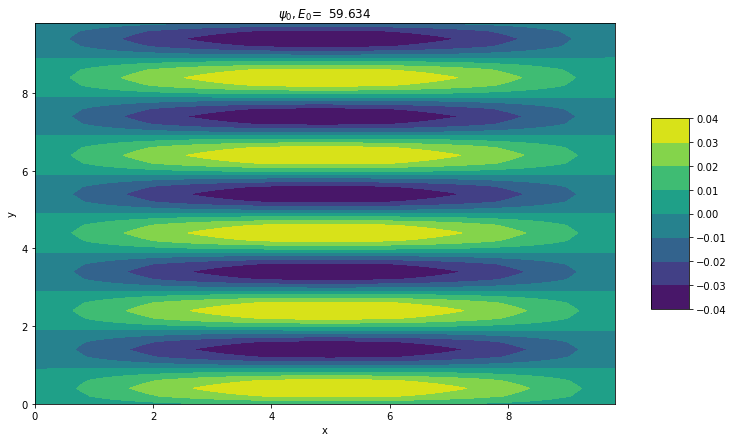

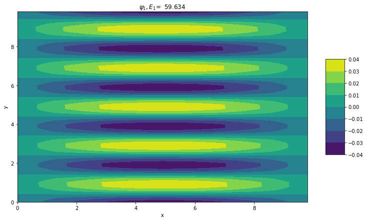

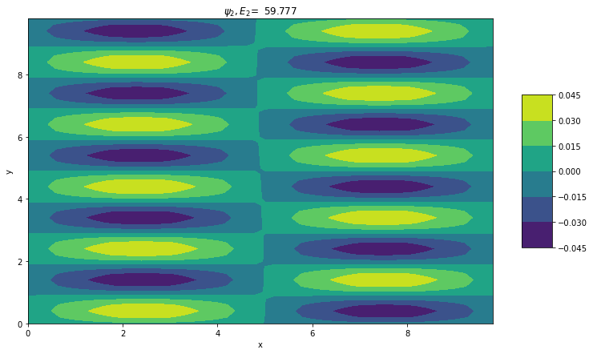

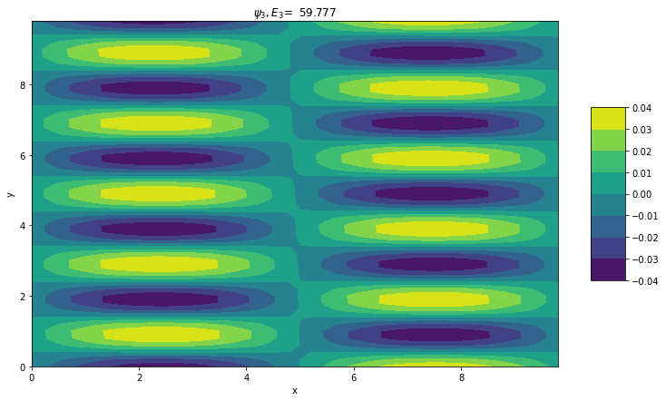

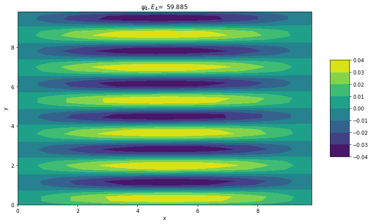

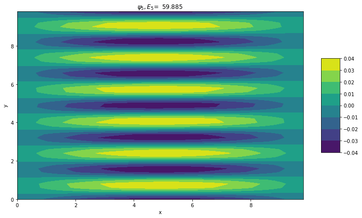

```python
hbar=1
m=1
N = 50
a = 10
h = a/N
x,y = np.mgrid[0:a:h, 0:a:h]
# x = np.linspace(0,a,N)
# y = np.linspace(0,a,N)

#Compute the derivative matrix
Mdd = 1./(h*h)*(np.diag(np.ones(N*N-1),-1) -4* np.diag(np.ones(N*N),0) + \
    np.diag(np.ones(N*N-1),1) + np.diag(np.ones(N*N-N),N) + \
    np.diag(np.ones(N*N-N),-N))


#Compute the Potential Matrix, replacing infinite values with large values
V = np.zeros((N*N,N*N))
for i in range(N*N):
    for j in range(N*N):
        temp = 1/(np.absolute(i-j)*h)
        if temp == np.inf:
            V[i,j] = 1/(0.1*h)
        else:
            V[i,j] = temp

#Sum the derivative matrix and potential matrix to get our full Hamiltonian
H = -(hbar*hbar)/(2.0*m)*Mdd + V



E,psiT = np.linalg.eigh(H) # This computes the eigen values and eigenvectors
psi = np.transpose(psiT)   # We take the transpose of psiT to the wavefunction vectors can accessed as psi[n]


#plot heatmaps of the eigenstates
for i in range(6):
    fig = plt.figure(figsize=(13, 7))
    ax = plt.axes()
    surf = ax.contourf(x, y, np.reshape(psi[i],(N,N)))
    ax.set_xlabel('x')
    ax.set_ylabel('y')
    ax.set_title("$\psi_{}, E_{}$={:>8.3f}".format(i, i,E[i]))
    fig.colorbar(surf, shrink=0.5, aspect=5) # add color bar indicating the PDF
```